# Lab 7

Nathan Preuss

12 November, 2020

# 1 Task 1

Working Directory

```r
getwd()
```

```
## [1] "C:/Users/Nathan/Documents/R_Projects/MATH4753PREU0001/Lab7"
```

# 2 Task 2

## 2.1 4 Plots

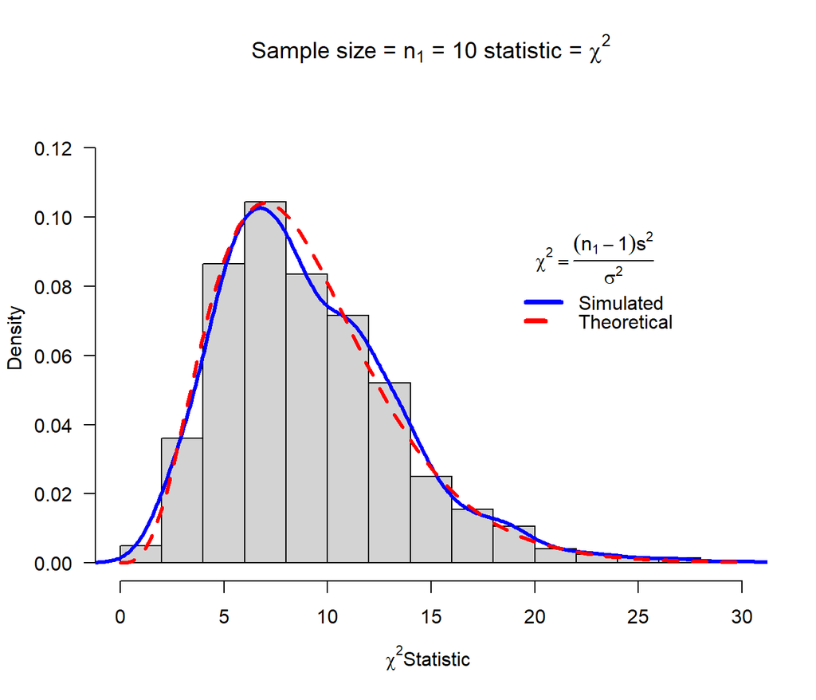

```r
#This is a model R function that you can alter for other statistics
# Copy this function twice and alter the two copies to make sampling distributions from the T distribution
mychisim<-function(n1=10,sigma1=3,mean1=5,iter=1000,ymax=0.1,...){    # adjust ymax to make graph fit
y1=rnorm(n1*iter,mean=mean1,sd=sigma1)# generate iter samples of size n1

data1.mat=matrix(y1,nrow=n1,ncol=iter,byrow=TRUE) # Each column is a sample size n1

ssq1=apply(data1.mat,2,var) # ssq1 is s squared

w=(n1-1)*ssq1/sigma1^2      #chi-sq stat

hist(w,freq=FALSE, ylim=c(0,ymax), # Histogram with annotation
main=substitute(paste("Sample size = ",n[1]," = ",n1," statistic = ",chi^2)),
xlab=expression(paste(chi^2, "Statistic",sep=" ")), las=1)
lines(density(w),col="Blue",lwd=3) # add a density plot
curve(dchisq(x,n1-1),add=TRUE,col="Red",lty=2,lwd=3) # add a theoretical curve
title=expression(chi^2==frac((n[1]-1)*s^2,sigma^2)) #mathematical annotation -see ?plotmath
legend(locator(1),c("Simulated","Theoretical"),col=c("Blue","Red"),lwd=4,lty=1:2,bty="n",title=title) # Legend #
return(list(w=w,summary=summary(w),sd=sd(w),fun="Chi-sq")) # some output to use if needed
}
windows()
chism=mychisim(n1 = 10, iter=1000, sigma1 = 4, mean1 = 10, ymax=0.13)
```

```r
chism=mychisim(n1 = 20, iter=1000, sigma1 = 4, mean1 = 10, ymax=0.08)
```

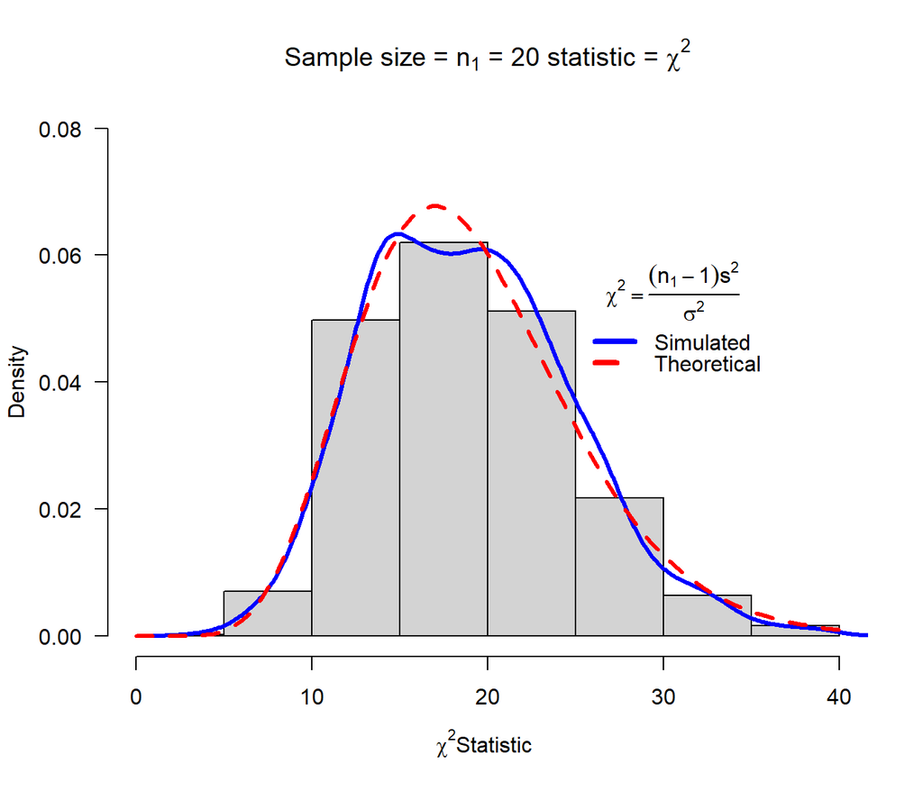

```r
chism=mychisim(n1 = 100, iter=1000, sigma1 = 4, mean1 = 10, ymax=0.04)
```

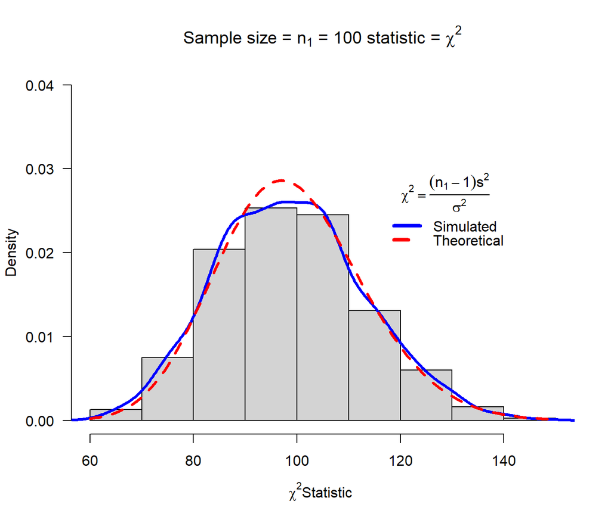

```r
chism=mychisim(n1 = 200, iter=1000, sigma1 = 4, mean1 = 10, ymax=0.025)
```

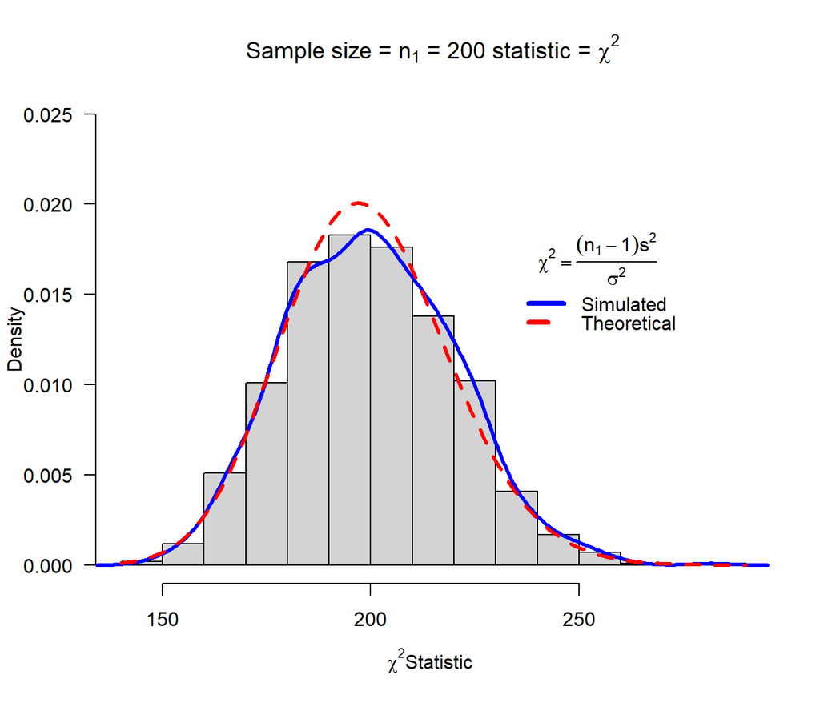

## 2.2 Histogram

```r
windows()
chisq=mychisim(n1 = 10, iter=1500, sigma1 = 10, mean1 = 20, ymax=0.15)
```

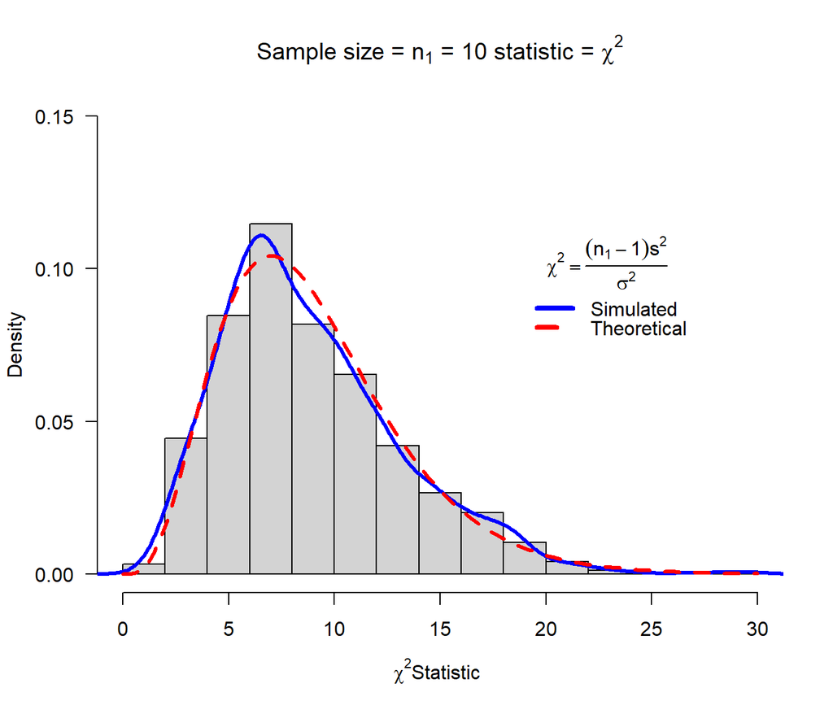

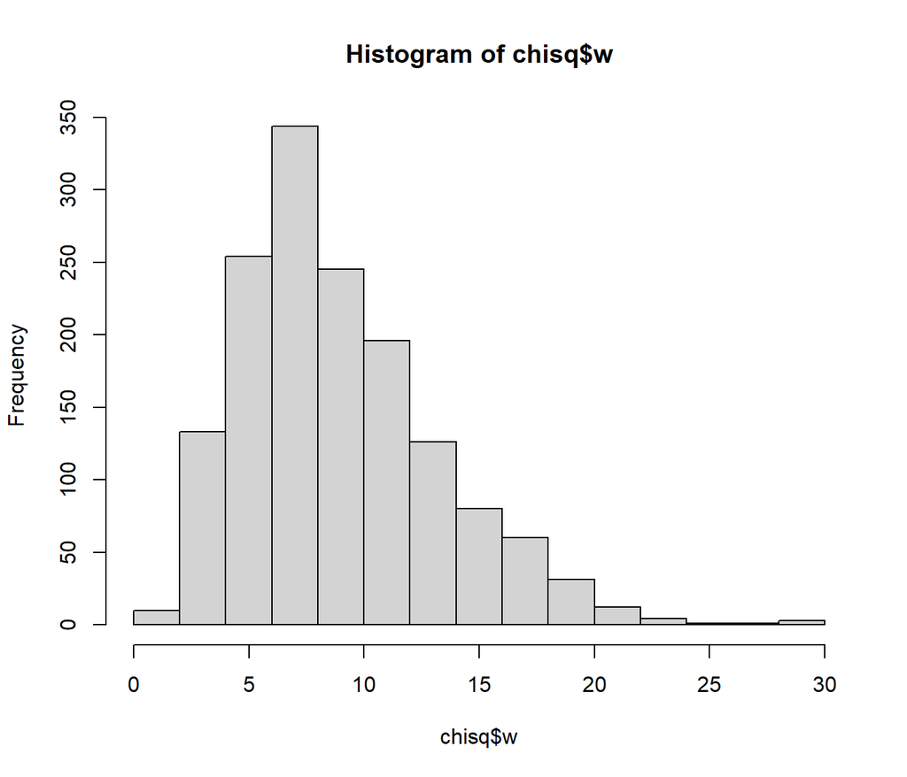

```r
hist(chisq$w)
```

# 3 Task 3

## 3.1 4 Plots

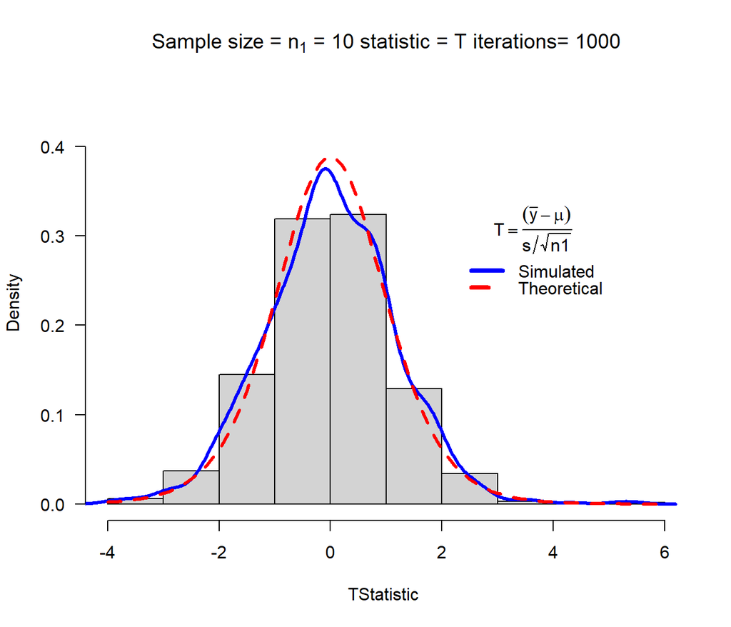

```r
myTsim<-function(n1=10,sigma1=3,mean1=5,iter=1000,ymax=0.1,...){    # adjust ymax to make graph fit
y1=rnorm(n1*iter,mean=mean1,sd=sigma1)# generate iter samples of size n1

data1.mat=matrix(y1,nrow=n1,ncol=iter,byrow=TRUE) # Each column is a sample size n1

sd1=apply(data1.mat,2,sd) # sd
ybar=apply(data1.mat,2,mean)  # mean

w=(ybar-mean1)/(sd1/sqrt(n1))      #T stat

hist(w,freq=FALSE, ylim=c(0,ymax), # Histogram with annotation
main=substitute(paste("Sample size = ",n[1]," = ",n1," statistic = ",T," iterations= ",iter)),
xlab=expression(paste(T, "Statistic",sep=" ")), las=1)
lines(density(w),col="Blue",lwd=3) # add a density plot
curve(dt(x,n1-1),add=TRUE,col="Red",lty=2,lwd=3) # add a theoretical curve
title=expression(T==frac((bar(y)-mu),s/sqrt(n1))) #mathematical annotation -see ?plotmath
legend(locator(1),c("Simulated","Theoretical"),col=c("Blue","Red"),lwd=4,lty=1:2,bty="n",title=title) # Legend #
return(list(w=w,summary=summary(w),sd=sd(w),fun="T")) # some output to use if needed
}
windows()
tsim = myTsim(n1 = 10, iter=1000, mean1= 10, sigma1 = 4, ymax=0.45)
```

```r
tsim = myTsim(n1 = 20, iter=1000, mean1= 10, sigma1 = 4, ymax=0.45)
```

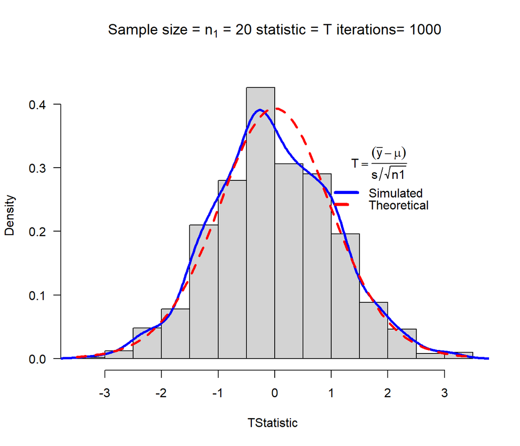

```r
tsim = myTsim(n1 = 100, iter=1000, mean1= 10, sigma1 = 4, ymax=0.45)
```

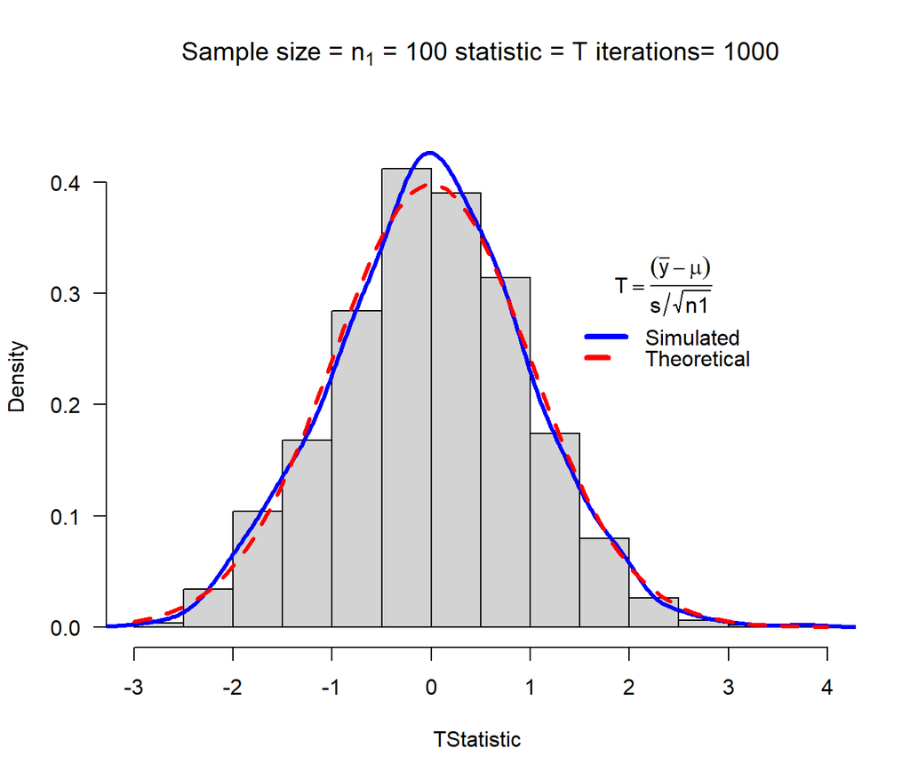

```r
tsim = myTsim(n1 = 200, iter=1000, mean1= 10, sigma1 = 4, ymax=0.45)
```

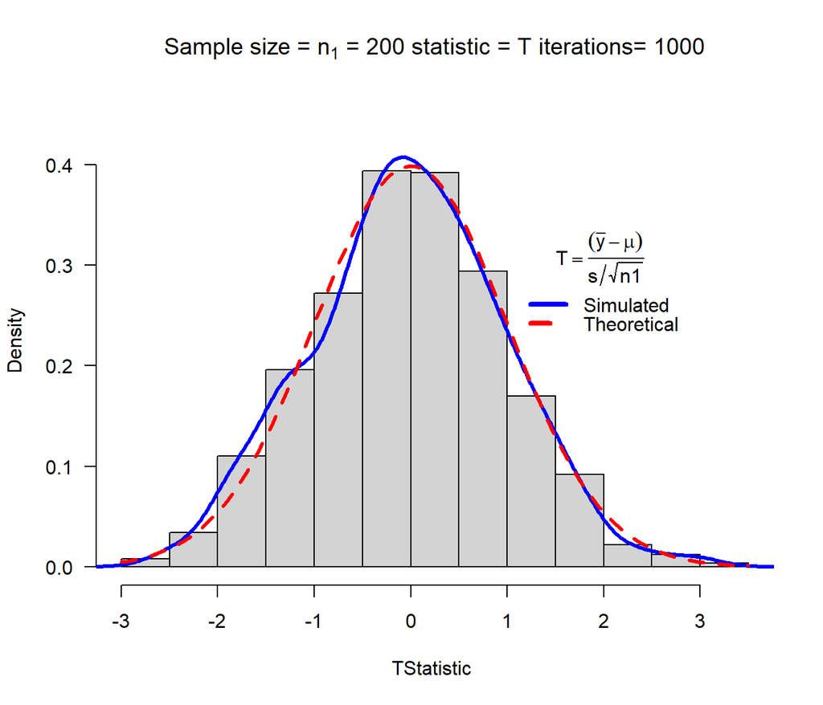

## 3.2 Histogram

```r
windows()
tsim = myTsim(n1 = 10, iter=1500, mean1=20, sigma1=10, ymax=.45)
```

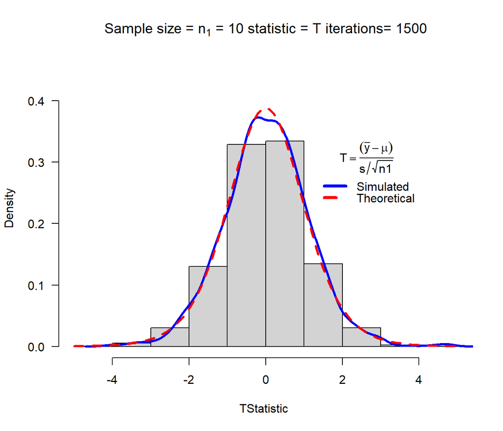

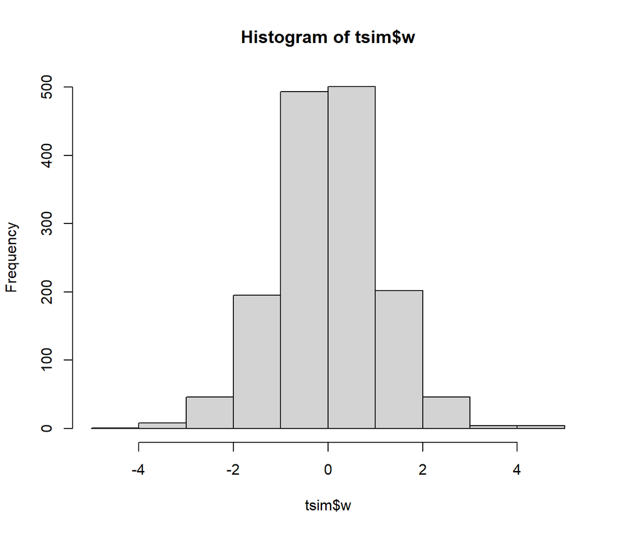

```r
hist(tsim$w)
```

# 4 Task 4

## 4.1 4 Plots

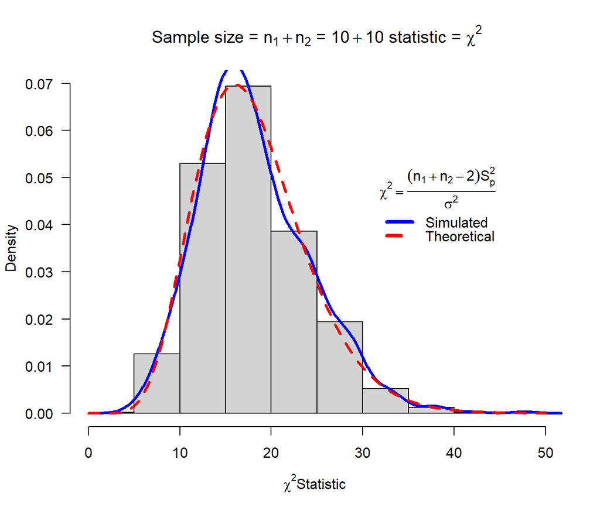

```r
#### Two pop sampling
mychisim2<-function(n1=10,n2=14,sigma1=3,sigma2=3,mean1=5,mean2=10,iter=1000,ymax=0.07,...){    # adjust ymax to make graph fit
y1=rnorm(n1*iter,mean=mean1,sd=sigma1)# generate iter samples of size n1
y2=rnorm(n2*iter,mean=mean2,sd=sigma2)
data1.mat=matrix(y1,nrow=n1,ncol=iter,byrow=TRUE) # Each column is a sample size n1
data2.mat=matrix(y2,nrow=n2,ncol=iter,byrow=TRUE)
ssq1=apply(data1.mat,2,var) # ssq1 is s squared
ssq2=apply(data2.mat,2,var)
spsq=((n1-1)*ssq1 + (n2-1)*ssq2)/(n1+n2-2) # pooled s squared
w=(n1+n2-2)*spsq/(sigma1^2)#sigma1=sigma2,  Chi square stat
hist(w,freq=FALSE, ylim=c(0,ymax), # Histogram with annotation
main=substitute(paste("Sample size = ",n[1]+n[2]," = ",n1+n2," statistic = ",chi^2)),
xlab=expression(paste(chi^2, "Statistic",sep=" ")), las=1)
lines(density(w),col="Blue",lwd=3) # add a density plot
curve(dchisq(x,n1+n2-2),add=TRUE,col="Red",lty=2,lwd=3) # add a theoretical curve
title=expression(chi^2==frac((n[1]+n[2]-2)*S[p]^2,sigma^2)) #mathematical annotation -see ?plotmath
legend(locator(1),c("Simulated","Theoretical"),col=c("Blue","Red"),lwd=4,lty=1:2,bty="n",title=title) # Legend #
return(list(w=w,summary=summary(w),sd=sd(w),fun="Chi-sq")) # some output to use if needed
}
windows()
chi2 = mychisim2(n1 = 10, n2 = 10, mean1 = 5, mean2= 10, sigma1 = 4, sigma2 = 4, iter=1000)
```

```r
chi2= mychisim2(n1 = 20, n2 = 10, mean1 = 3, mean2= 5, sigma1 = 10, sigma2 = 10, iter=1000)
```

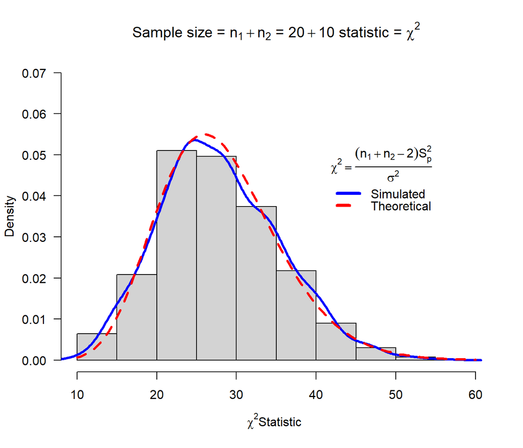

```r
chi2 = mychisim2(n1 = 50, n2 = 50, mean1 = 5, mean2= 10, sigma1 = 4, sigma2 = 4, iter=10000, ymax=0.035)
```

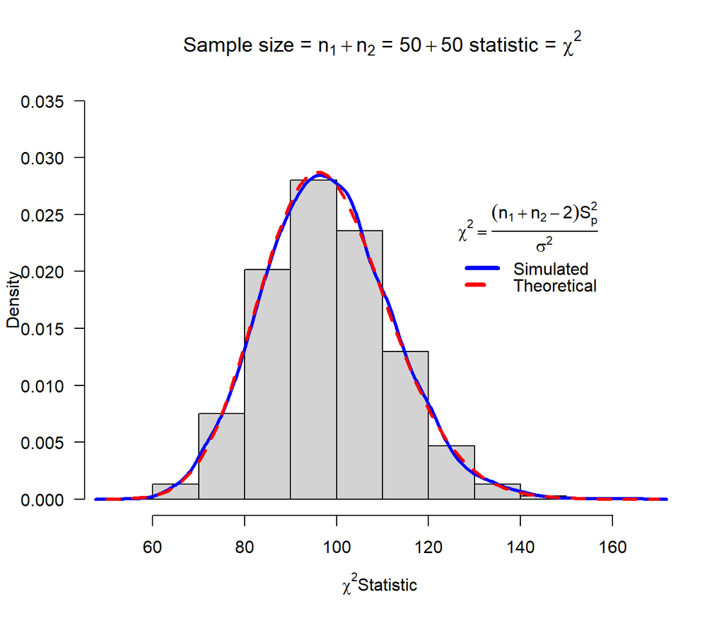

```r
chi2 = mychisim2(n1 = 80, n2 = 50, mean1 = 3, mean2= 5, sigma1 = 10, sigma2 = 10, iter=10000, ymax = 0.035)
```

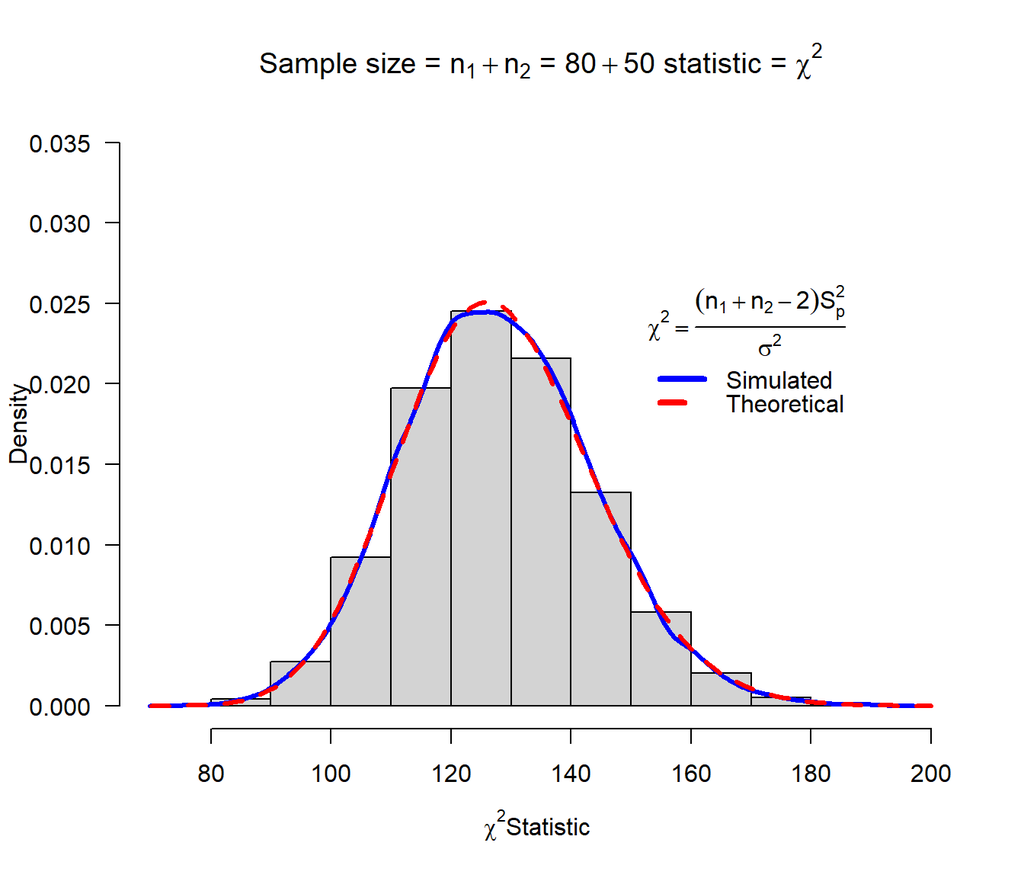

## 4.2 Histogram

```r
windows()
chi2 = mychisim2(iter=10000)
```

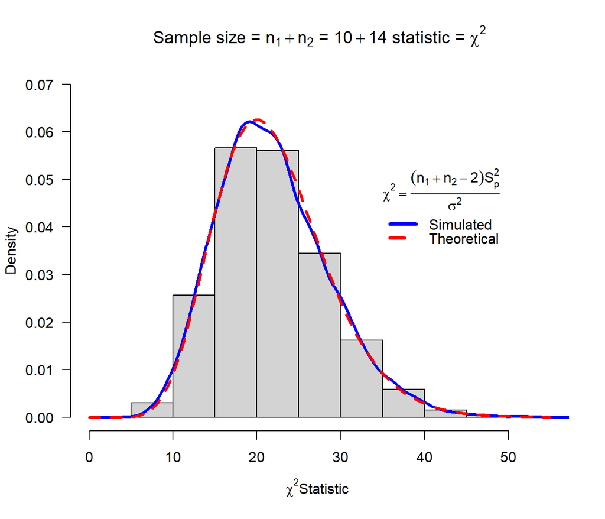

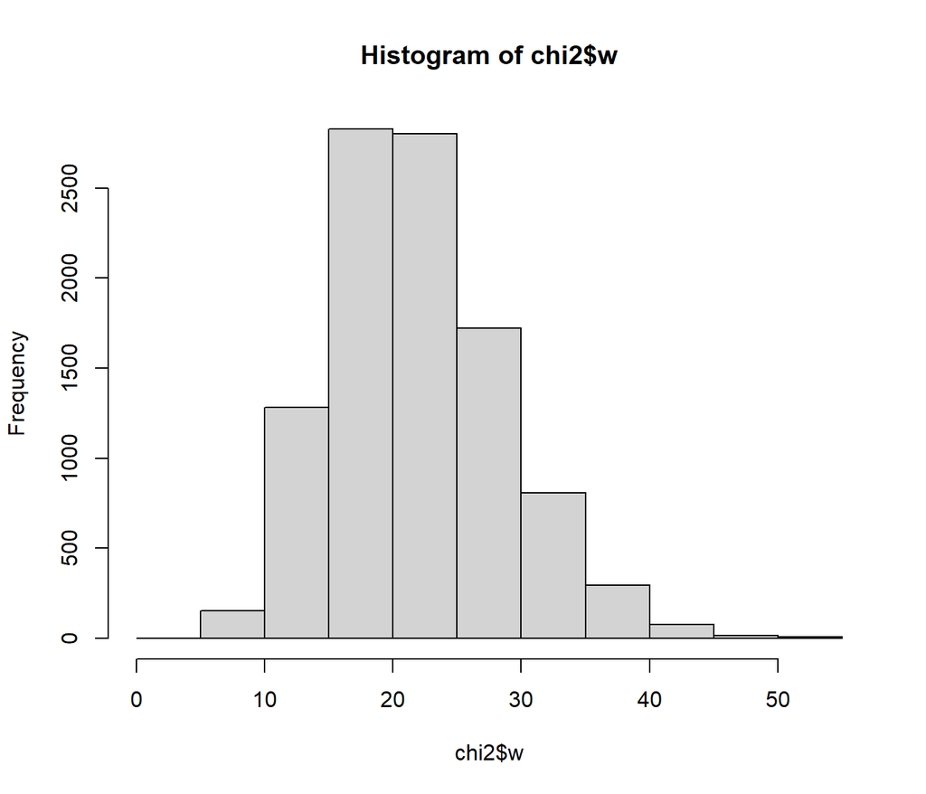

```r
hist(chi2$w)
```

# 5 Task 5

## 5.1 T Statistic Notation

The Student’s T statistic is given as:
$$T = \frac{Z} {\sqrt{\chi^2/v}} = \frac{(\overline Y_1 - \overline Y_2) - (\mu_1-\mu_2)}{S_p\sqrt{\frac{1} {n_1}+ \frac{1}{n_2}}}$$
where
$$S^2_p = \frac{(n_1 - 1)S^2_1 + (n_2 - 1)S^2_2} {n_1 + n_2 - 2}$$
and
$$v= (n_1 + n_2 - 2)$$
Degrees of freedom.

Let’s break down this function into more depth.
$$Z = \frac{\overline Y - \mu}{\sigma/\sqrt{n}}$$
We know that both of the sample means are normally distributed by Theorem 6.10 from the textbook, so we know that Z is a standard normal variable. Because we are doing the T statistic for two variables, we will use a $Z_1$ and $Z_2$.

Furthermore, we know that $\chi^2$ is a chi-squared random variable with $v=n-1$ degrees of freedom. Because there are two populations, we end up with $v = n_1 + n_2 - 2$ degrees of freedom. Then, using the values that we calculated for Z earlier, the definition for chi squared, and because $\overline Y_1, \overline Y_2$ and $S_1^2, S^2_2$ are independent, we can expand $T$ into $\frac{(\overline Y_1 - \overline Y_2) - (\mu_1-\mu_2)}{S_p\sqrt{\frac{1} {n_1}+ \frac{1}{n_2}}}$

## 5.2 4 Plots

Edited to place the legend when the graph is clicked on.

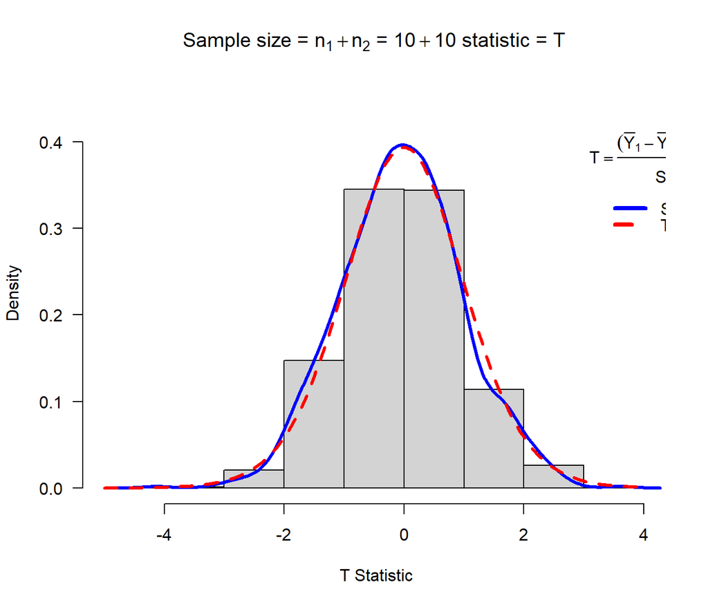

```r
myTsim2<-function(n1=10,n2=14,sigma1=3,sigma2=3,mean1=5,mean2=10,iter=1000,ymax=0.45,...){
y1=rnorm(n1*iter,mean=mean1,sd=sigma1)# generate iter samples of size n1
y2=rnorm(n2*iter,mean=mean2,sd=sigma2)
data1.mat=matrix(y1,nrow=n1,ncol=iter,byrow=TRUE) # Each column is a sample size n1
data2.mat=matrix(y2,nrow=n2,ncol=iter,byrow=TRUE)
ssq1=apply(data1.mat,2,var) # ssq1 is s squared
ybar1= apply(data1.mat,2,mean)
ssq2=apply(data2.mat,2,var)
ybar2=apply(data2.mat,2,mean)
spsq=((n1-1)*ssq1 + (n2-1)*ssq2)/(n1+n2-2) # pooled s squared
w=((ybar1-ybar2)-(mean1-mean2))/sqrt(spsq*(1/n1+1/n2))#sigma1=sigma2,  Chi square stat
hist(w,freq=FALSE, ylim=c(0,ymax), # Histogram with annotation
main=substitute(paste("Sample size = ",n[1]+n[2]," = ",n1+n2," statistic = ",T)),
xlab=paste(" T Statistic",sep=""), las=1)
lines(density(w),col="Blue",lwd=3) # add a density plot
curve(dt(x,n1+n2-2),add=TRUE,col="Red",lty=2,lwd=3) # add a theoretical curve
title=expression(T==frac((bar(Y)[1]-bar(Y)[2])-(mu[1]-mu[2]),S[p]*sqrt(frac(1,n[1])+frac(1,n[2])))) #mathematical annotation -see ?plotmath
legend(locator(1),c("Simulated","Theoretical"),col=c("Blue","Red"),lwd=4,lty=1:2,bty="n",title=title)# Legend #
return(list(w=w,summary=summary(w),sdw=sd(w),fun="T")) # some output to use if needed
}
windows()
tsim = myTsim2(n1 = 10, n2 = 10, mean1 = 5, mean2= 10, sigma1=4, sigma2 = 4, iter=1000)
```

```r
tsim = myTsim2(n1 = 20, n2 = 10, mean1 = 3, mean2= 5, sigma1=10, sigma2 = 10, iter=1000)
```

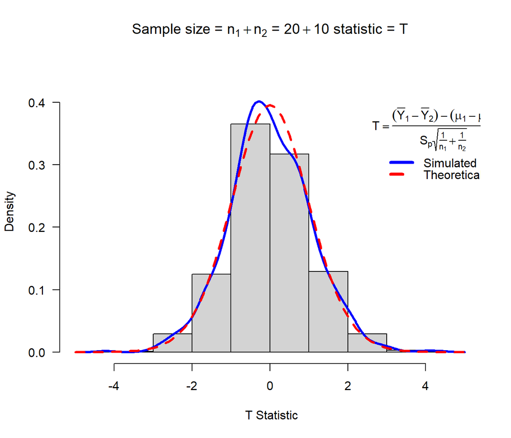

```r
tsim = myTsim2(n1 = 50, n2 = 50, mean1 = 5, mean2= 10, sigma1=4, sigma2 = 4, iter=10000)
```

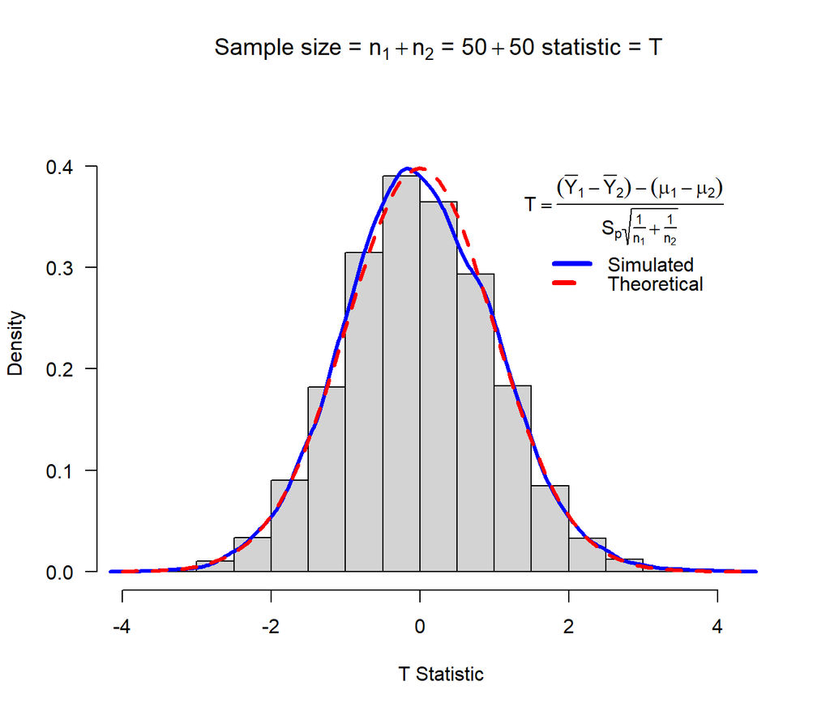

```r
tsim = myTsim2(n1 = 80, n2 = 50, mean1 = 3, mean2= 5, sigma1=10, sigma2 = 10, iter=10000)
```

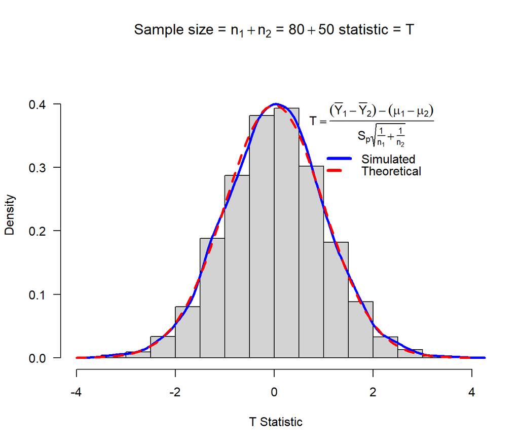

## 5.3 Histogram

```r
windows()
tsmi = myTsim2(iter=10000)
```

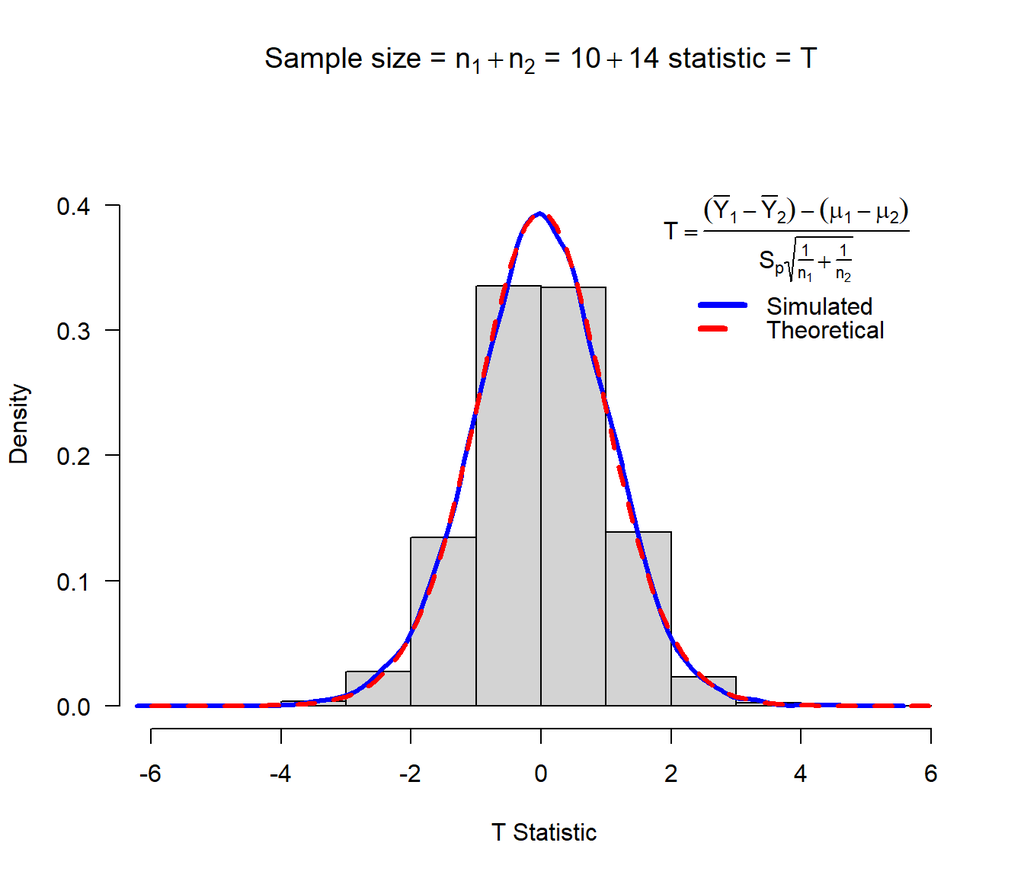

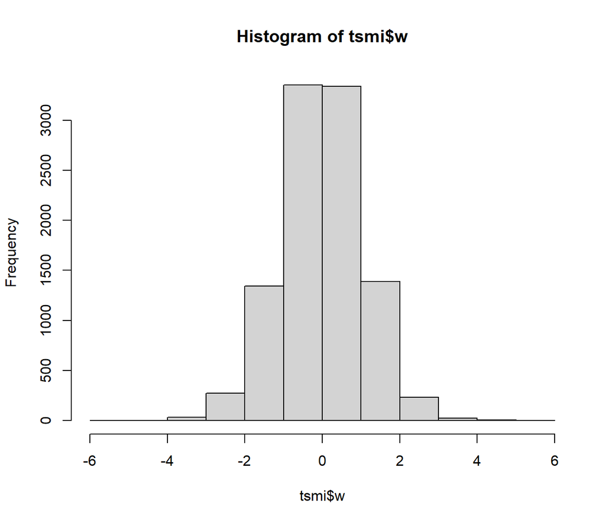

```r
hist(tsmi$w)
```

# 6 Task 6

## 6.1 F statistic

F statistic will calculate $F = (\frac{S^2_1}{S^2_2})(\frac{\sigma^2_2}{\sigma^2_1})$. This assumes that $\chi^2_1$ and $\chi^2_2$ are chi-square random variables with $v_1$ and $v_2$ degrees of freedom, respectively. If the chi-squared variables are independent, then $F = \frac{\chi^2_1/v_1} {\chi^2_2/v_2}$, with $v_1$ numerator degrees of freedom and $v_2$ denominator degrees of freedom. This can be simplified to $F = (\frac{S^2_1}{S^2_2})(\frac{\sigma^2_2}{\sigma^2_1})$.

## 6.2 4 Plots

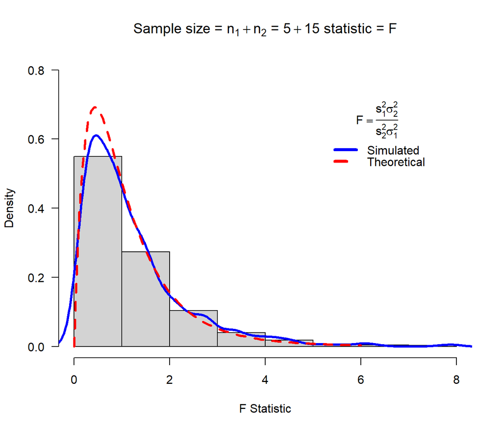

```r
myFsim2<-function(n1=10,n2=14,sigma1=3,sigma2=2,mean1=5,mean2=10,iter=1000,ymax=0.9,...){
y1=rnorm(n1*iter,mean=mean1,sd=sigma1)# generate iter samples of size n1
y2=rnorm(n2*iter,mean=mean2,sd=sigma2)
data1.mat=matrix(y1,nrow=n1,ncol=iter,byrow=TRUE) # Each column is a sample size n1
data2.mat=matrix(y2,nrow=n2,ncol=iter,byrow=TRUE)
ssq1=apply(data1.mat,2,var) # ssq1 is s squared
ssq2=apply(data2.mat,2,var)
#spsq=((n1-1)*ssq1 + (n2-1)*ssq2)/(n1+n2-2) # pooled s squared
w=ssq1*sigma2^2/(ssq2*sigma1^2) #
hist(w,freq=FALSE, ylim=c(0,ymax), # Histogram with annotation
main=substitute(paste("Sample size = ",n[1]+n[2]," = ",n1+n2," statistic = ",F)),
xlab=paste("F Statistic",sep=""), las=1)
lines(density(w),col="Blue",lwd=3) # add a density plot
curve(df(x,n1-1,n2-1),xlim=c(0,6),add=TRUE,col="Red",lty=2,lwd=3) # add a theoretical curve
title=expression(F==frac(s[1]^2,s[2]^2)*frac(sigma[2]^2,sigma[1]^2)) #mathematical annotation -see ?plotmath
legend(locator(1),c("Simulated","Theoretical"),col=c("Blue","Red"),lwd=4,lty=1:2,bty="n",title=title)# Legend #
return(list(w=w,summary=summary(w),sd=sd(w),fun="F")) # some output to use if needed
}
windows()
fsim = myFsim2(n1 = 5, n2 = 15, sigma1 = 4, sigma2 = 4, mean1 = 6, mean2 = 8, iter=1000, ymax=.8)
```

```r
fsim = myFsim2(n1 = 15, n2 = 5, sigma1 = 3, sigma2 = 3, mean1 = 3, mean2 = 3, iter=1000, ymax=.8)
```

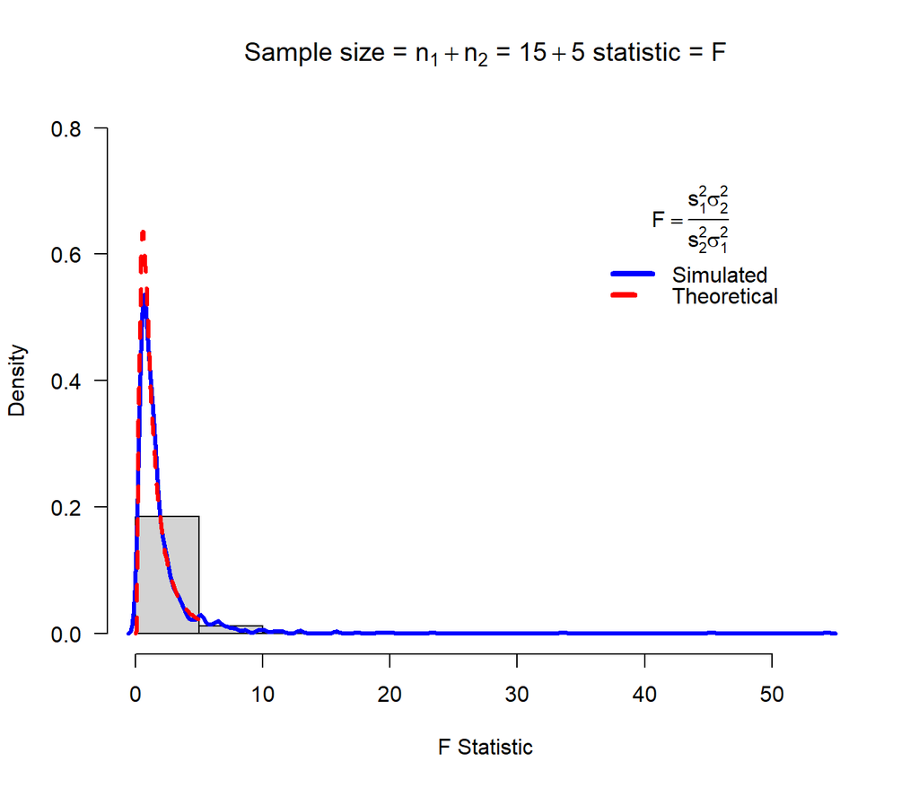

```r
fsim = myFsim2(n1 = 8, n2 = 12, sigma1 = 7, sigma2 = 7, mean1 = 9, mean2 = 5, iter=1000, ymax=.8)
```

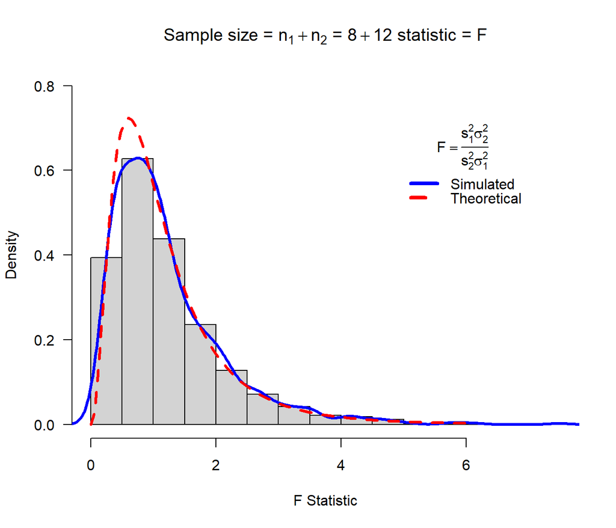

```r
fsim = myFsim2(n1 = 8, n2 = 9, sigma1 = 8, sigma2 = 8, mean1 = 1, mean2 = 7, iter=1000, ymax=.8)
```

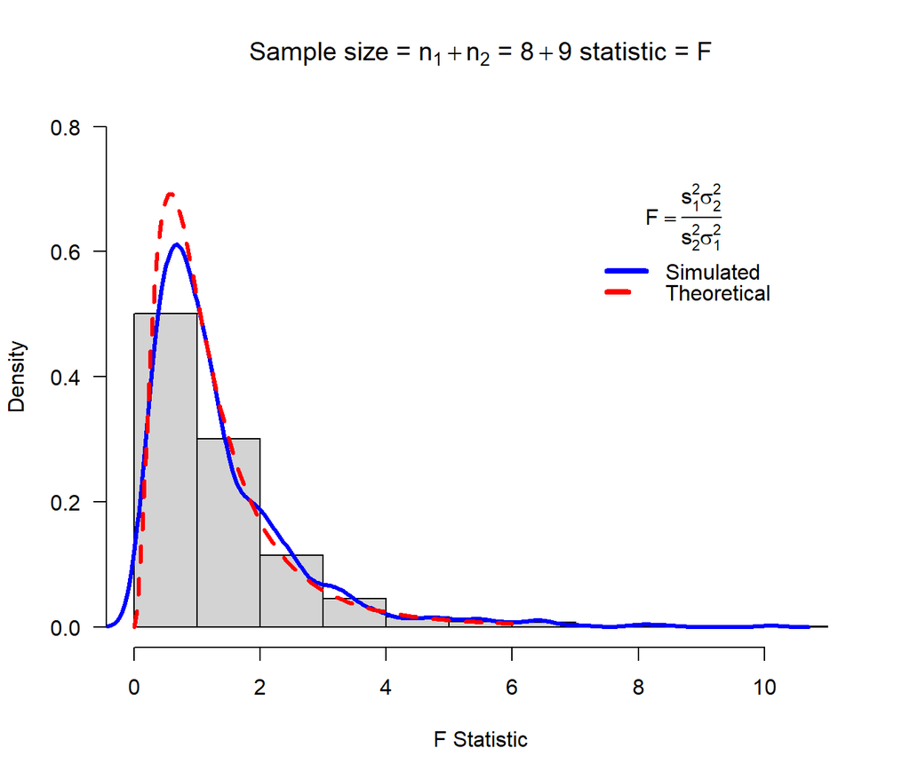

## 6.3 Histogram

```r
windows()
fsim = myFsim2()
```

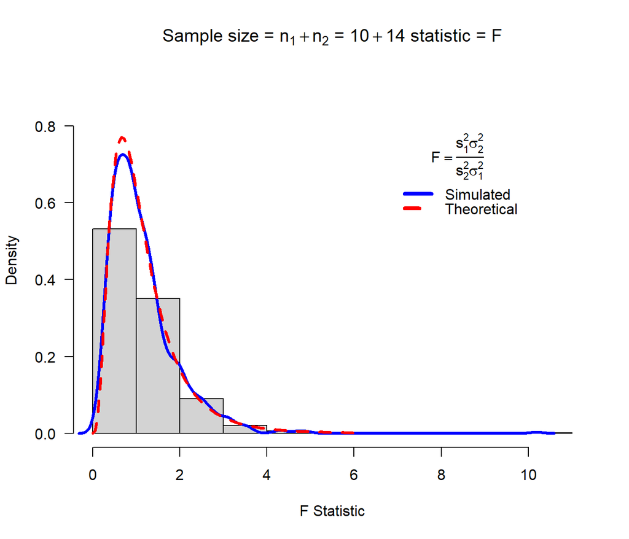

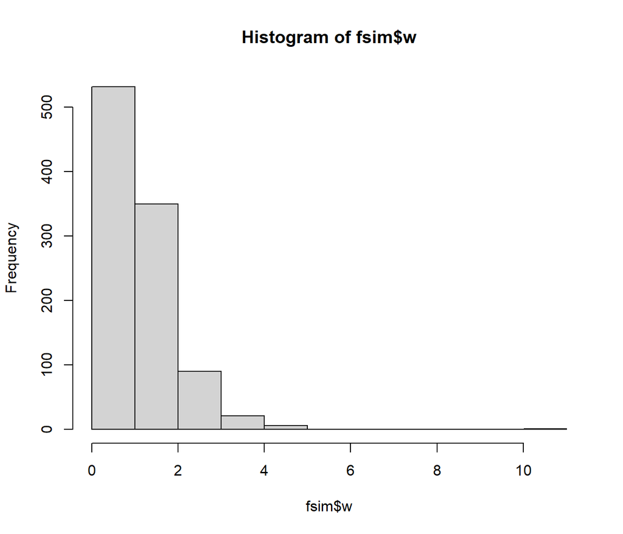

```r
hist(fsim$w)
```

# 7 Task 7

## 7.1 Data in the Package

```r
library(MATH4753PREU0001)
data("fire")
knitr::kable((head(fire)))
```

| DISTANCE | DAMAGE |
| --- | --- |
| 3.4 | 26.2 |
| 1.8 | 17.8 |
| 4.6 | 31.3 |
| 2.3 | 23.1 |
| 3.1 | 27.5 |
| 5.5 | 36.0 |